# Small seeding models for Tony & Kevin

Kathleen Stutzman

2024-01-25

Hidden below is code for importing the data set and log transforming variables. The best model (lowest AIC & using lrtest) is presented below, model fit checked, and pairwise comparison for Treatment Type.

I did create and test models without treatment type, but they always have higher AIC and worse model fit that those with (probably due to the control category…)

##### Variables investigated:

- **Treat_Type** - treatment type
- **PIRI** - pitch pine seedling count (1m<sup>2</sup>)
- **SO** - shrub oak seedling count (1m<sup>2</sup>)
- **other** - other seedling count (1m<sup>2</sup>)
- **BA_HA** - basal area per hectare
- **BA_piri** - pitch pine basal area per hectare
- **Mineral** - exposed mineral soil (1m<sup>2</sup>)
- **avgLD** - average leaf litter depth (1m<sup>2</sup>)
- **Veg_Total** - total understory plant cover (1m<sup>2</sup>)
- **TFT** - time between treatment and sampling (used as an offset)
- **Site/Plot_No** - random effect of plots within sites

*Variables are log transformed (l. or _l)*

## Pitch Pine Regeneration

### Best small seedling pitch pine model

```r
ss.m4 <- glmmTMB(PIRI ~ Treat_Type + l.SO + avgLD_l + l.Veg_Total + offset(l.TFT) + (1|Site/Plot_No),
                 data = ss.all2,
                 family = poisson)
summary(ss.m4)
```

```
##  Family: poisson  ( log )
## Formula:
## PIRI ~ Treat_Type + l.SO + avgLD_l + l.Veg_Total + offset(l.TFT) +
##     (1 | Site/Plot_No)
## Data: ss.all2
##
##      AIC      BIC   logLik deviance df.resid
##    722.6    764.7   -351.3    702.6      488
##
## Random effects:
##
## Conditional model:
##  Groups       Name        Variance Std.Dev.
##  Plot_No:Site (Intercept) 4.656    2.158
##  Site         (Intercept) 2.247    1.499
## Number of obs: 498, groups:  Plot_No:Site, 498; Site, 47
##
## Conditional model:
##                    Estimate Std. Error z value   Pr(>|z|)
## (Intercept)         -5.2343     1.7869  -2.929    0.00340 **
## Treat_TypeFallRx     6.8805     1.4362   4.791 0.00000166 ***
## Treat_TypeHarvest    6.4779     1.5011   4.315 0.00001594 ***
## Treat_TypeMowRx      5.2750     1.4183   3.719    0.00020 ***
## Treat_TypeSpringRx   6.7833     1.4406   4.709 0.00000250 ***
## l.SO                -0.5173     0.2390  -2.164    0.03045 *
## avgLD_l             -1.1968     0.4340  -2.757    0.00583 **
## l.Veg_Total         -0.8030     0.3279  -2.449    0.01431 *
## ---
## Signif. codes:  0 '***' 0.001 '**' 0.01 '*' 0.05 '.' 0.1 ' ' 1
```

### Check model fit

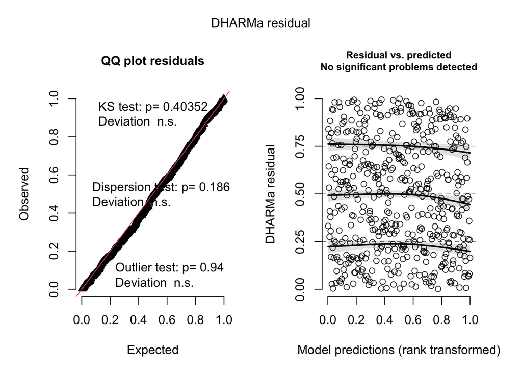

```r
ss.m4_sr <- simulateResiduals(ss.m4, n = 1000, plot = TRUE) #looks pretty good
```

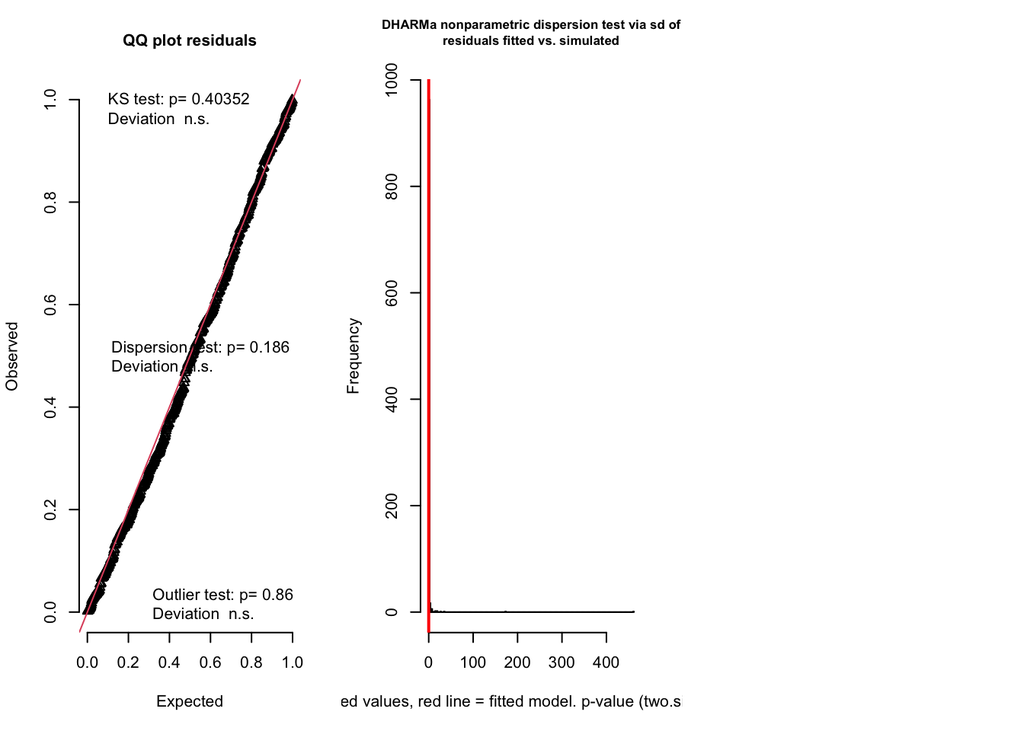

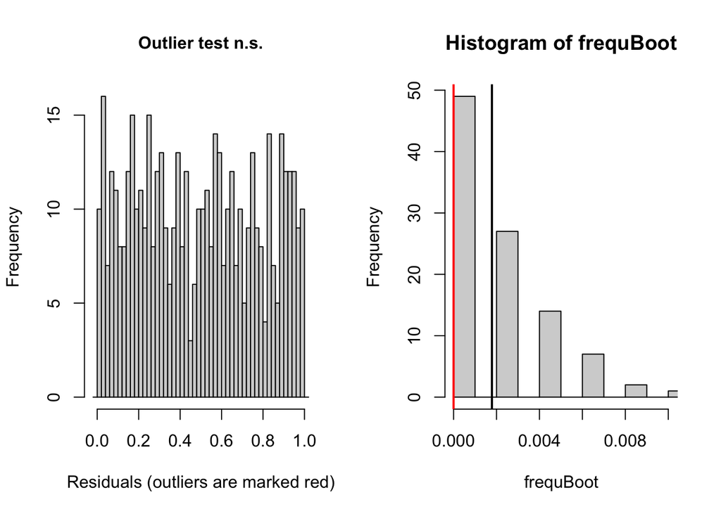

```
## $uniformity
##
##  Asymptotic one-sample Kolmogorov-Smirnov test
##
## data:  simulationOutput$scaledResiduals
## D = 0.039983, p-value = 0.4035
## alternative hypothesis: two-sided
##
##
## $dispersion
##
##  DHARMa nonparametric dispersion test via sd of residuals fitted vs.
##  simulated
##
## data:  simulationOutput
## dispersion = 0.0036142, p-value = 0.186
## alternative hypothesis: two.sided
##
##
## $outliers
##
##  DHARMa bootstrapped outlier test
##
## data:  simulationOutput
## outliers at both margin(s) = 0, observations = 498, p-value = 0.98
## alternative hypothesis: two.sided
##  percent confidence interval:
##  0.000000000 0.007078313
## sample estimates:
## outlier frequency (expected: 0.00178714859437751 )
##                                                  0
```

```
## $uniformity
##
##  Asymptotic one-sample Kolmogorov-Smirnov test
##
## data:  simulationOutput$scaledResiduals
## D = 0.039983, p-value = 0.4035
## alternative hypothesis: two-sided
##
##
## $dispersion
##
##  DHARMa nonparametric dispersion test via sd of residuals fitted vs.
##  simulated
##
## data:  simulationOutput
## dispersion = 0.0036142, p-value = 0.186
## alternative hypothesis: two.sided
##
##
## $outliers
##
##  DHARMa bootstrapped outlier test
##
## data:  simulationOutput
## outliers at both margin(s) = 0, observations = 498, p-value = 0.98
## alternative hypothesis: two.sided
##  percent confidence interval:
##  0.000000000 0.007078313
## sample estimates:
## outlier frequency (expected: 0.00178714859437751 )
##                                                  0
```

```r
testResiduals(ss.m4_sr) #passes uniformity, dispersion, and outliers
```

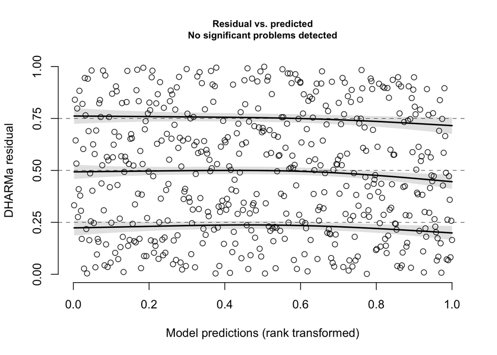

```
##
##  Test for location of quantiles via qgam
##
## data:  simulationOutput
## p-value = 0.655
## alternative hypothesis: both
```

```r
testQuantiles(ss.m4_sr) #passes
```

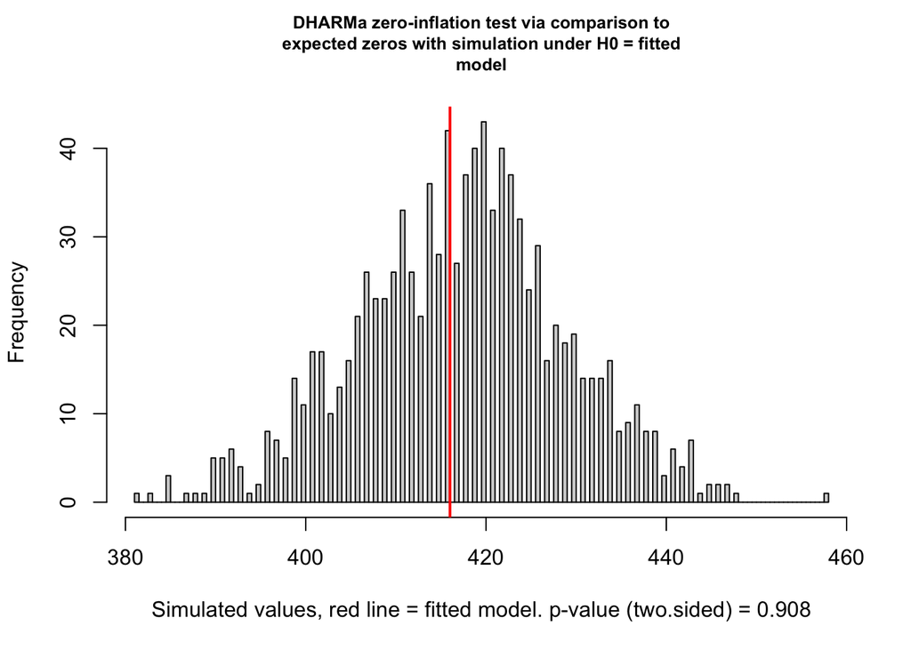

```
##
##  DHARMa zero-inflation test via comparison to expected zeros with
##  simulation under H0 = fitted model
##
## data:  simulationOutput
## ratioObsSim = 0.99644, p-value = 0.908
## alternative hypothesis: two.sided
```

```r
testZeroInflation(ss.m4_sr) #passes
```

### Pairwise for treatment type

```r
emmeans(ss.m4, specs = pairwise ~ Treat_Type, adjust = 'Tukey', type = 'response')
```

```
## $emmeans
##  Treat_Type     rate       SE  df asymp.LCL asymp.UCL
##  Control    0.000147 0.000196 Inf 0.0000108     0.002
##  FallRx     0.143080 0.098068 Inf 0.0373384     0.548
##  Harvest    0.095658 0.081203 Inf 0.0181195     0.505
##  MowRx      0.028729 0.019962 Inf 0.0073602     0.112
##  SpringRx   0.129823 0.093717 Inf 0.0315418     0.534
##
## Confidence level used: 0.95
## Intervals are back-transformed from the log scale
##
## $contrasts
##  contrast             ratio      SE  df null z.ratio p.value
##  Control / FallRx   0.00103 0.00148 Inf    1  -4.791  <.0001
##  Control / Harvest  0.00154 0.00231 Inf    1  -4.315  0.0002
##  Control / MowRx    0.00512 0.00726 Inf    1  -3.719  0.0019
##  Control / SpringRx 0.00113 0.00163 Inf    1  -4.709  <.0001
##  FallRx / Harvest   1.49575 1.48408 Inf    1   0.406  0.9943
##  FallRx / MowRx     4.98025 4.23364 Inf    1   1.889  0.3234
##  FallRx / SpringRx  1.10211 0.97169 Inf    1   0.110  1.0000
##  Harvest / MowRx    3.32961 3.28774 Inf    1   1.218  0.7408
##  Harvest / SpringRx 0.73683 0.73931 Inf    1  -0.304  0.9981
##  MowRx / SpringRx   0.22130 0.18901 Inf    1  -1.766  0.3936
##
## P value adjustment: tukey method for comparing a family of 5 estimates
## Tests are performed on the log scale
```

#### FallRx, Harvest, MowRx, SpringRx all significantly different from Control - no treatment significantly different from another

### Graph pitch pine models

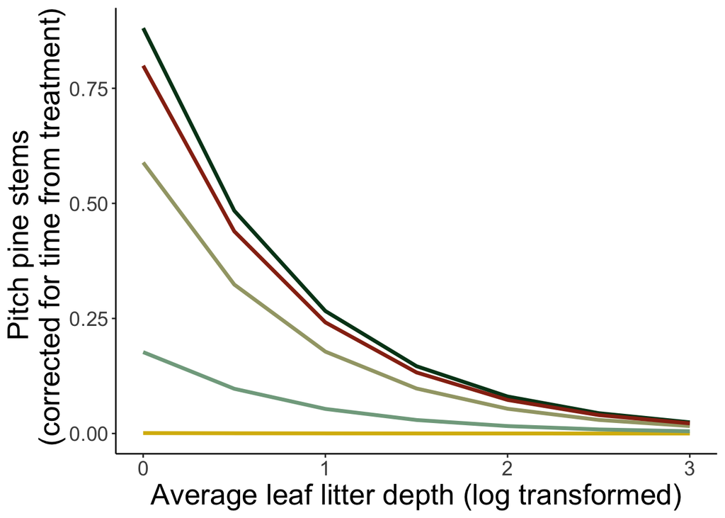

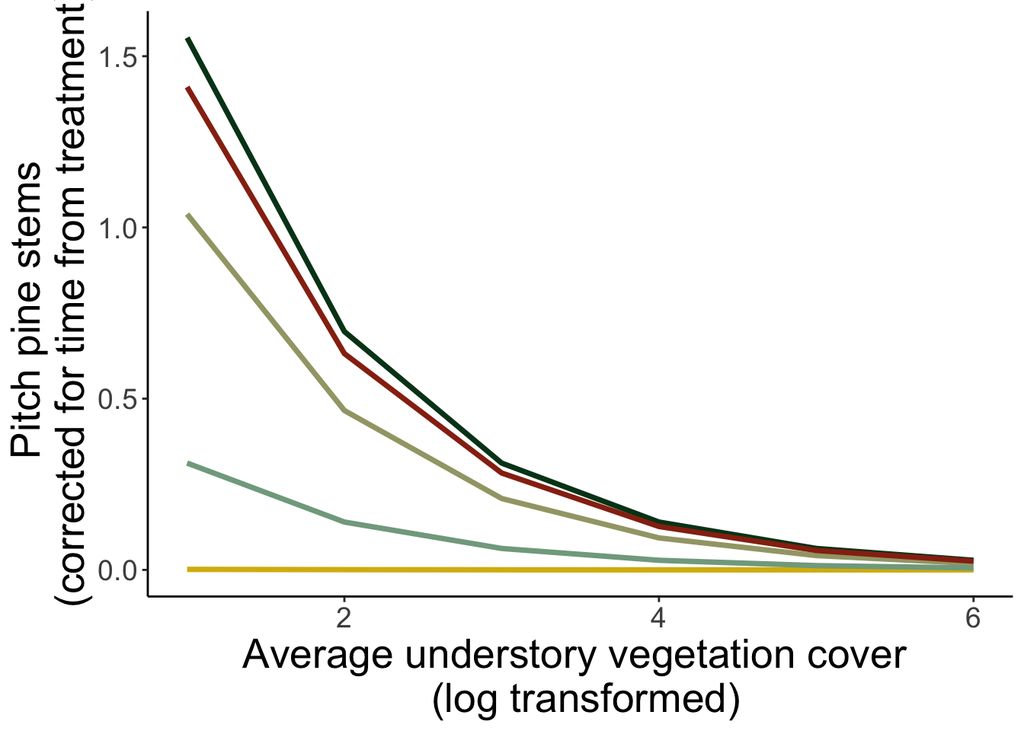

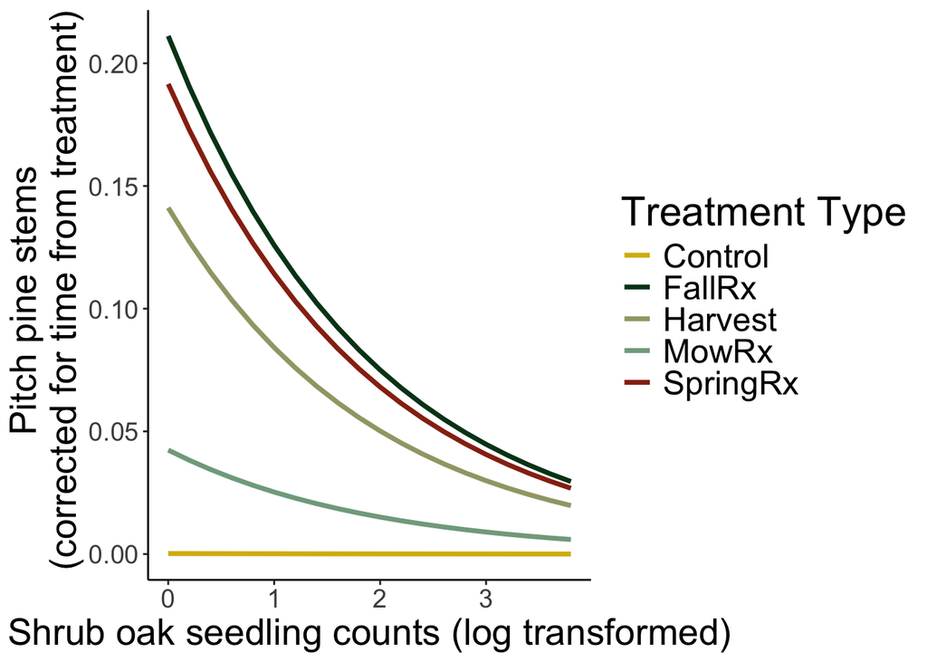

## Shrub Oak Regeneration

This includes QUIL (scrub oak) & QUPR (dwarf chinkapin oak)

### Best small seedling shrub oak model

```r
so.ss8a <- glmmTMB(Shrub_Oak ~ Treat_Type + offset(l.TFT) + (1|Site/Plot_No),
                 data = ss.all2,
                 ziformula = ~Region,
                 family = nbinom1)
summary(so.ss8a)
```

```
##  Family: nbinom1  ( log )
## Formula:          Shrub_Oak ~ Treat_Type + offset(l.TFT) + (1 | Site/Plot_No)
## Zero inflation:             ~Region
## Data: ss.all2
##
##      AIC      BIC   logLik deviance df.resid
##   1845.2   1900.0   -909.6   1819.2      485
##
## Random effects:
##
## Conditional model:
##  Groups       Name        Variance Std.Dev.
##  Plot_No:Site (Intercept) 0.1959   0.4426
##  Site         (Intercept) 1.1781   1.0854
## Number of obs: 498, groups:  Plot_No:Site, 498; Site, 47
##
## Dispersion parameter for nbinom1 family (): 2.66
##
## Conditional model:
##                    Estimate Std. Error z value            Pr(>|z|)
## (Intercept)         -3.1156     0.4019  -7.753 0.00000000000000898 ***
## Treat_TypeFallRx     2.5356     0.5532   4.583 0.00000457282661421 ***
## Treat_TypeHarvest    1.5420     0.6928   2.226               0.026 *
## Treat_TypeMowRx      2.8265     0.5191   5.445 0.00000005188937651 ***
## Treat_TypeSpringRx   2.8205     0.5672   4.972 0.00000066162708330 ***
## ---
## Signif. codes:  0 '***' 0.001 '**' 0.01 '*' 0.05 '.' 0.1 ' ' 1
##
## Zero-inflation model:
##              Estimate Std. Error z value Pr(>|z|)
## (Intercept)   -1.1038     0.4144  -2.664  0.00773 **
## RegionLI       1.0358     0.7268   1.425  0.15414
## RegionMA       0.2202     0.4805   0.458  0.64670
## RegionME      -1.3485     0.6592  -2.046  0.04080 *
## RegionNH     -16.8256  3461.9033  -0.005  0.99612
## ---
## Signif. codes:  0 '***' 0.001 '**' 0.01 '*' 0.05 '.' 0.1 ' ' 1
```

### Check model fit

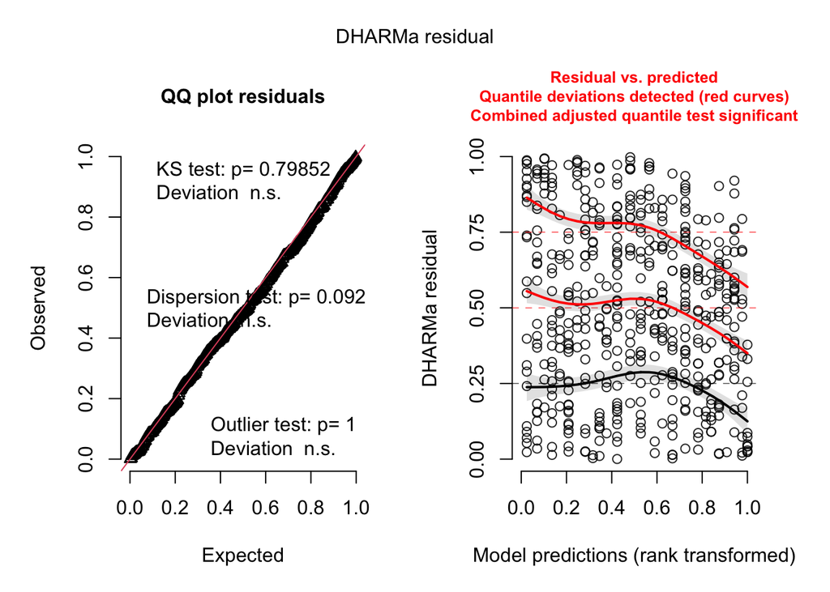

```r
so.ss8a_sr <- simulateResiduals(so.ss8a, n = 1000, plot = TRUE)
```

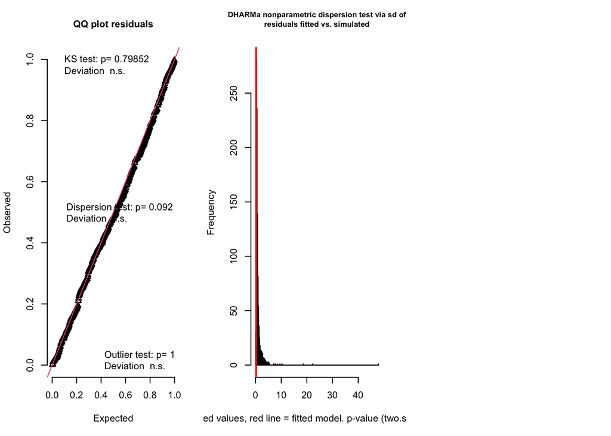

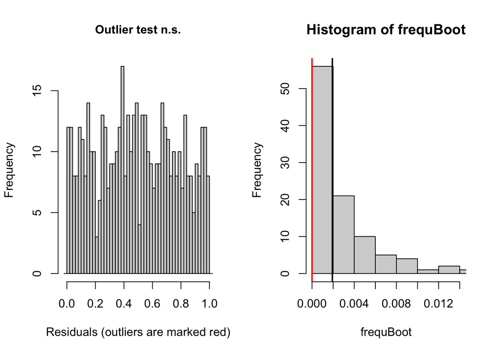

```
## $uniformity
##
##  Asymptotic one-sample Kolmogorov-Smirnov test
##
## data:  simulationOutput$scaledResiduals
## D = 0.028938, p-value = 0.7985
## alternative hypothesis: two-sided
##
##
## $dispersion
##
##  DHARMa nonparametric dispersion test via sd of residuals fitted vs.
##  simulated
##
## data:  simulationOutput
## dispersion = 0.23625, p-value = 0.092
## alternative hypothesis: two.sided
##
##
## $outliers
##
##  DHARMa bootstrapped outlier test
##
## data:  simulationOutput
## outliers at both margin(s) = 0, observations = 498, p-value = 1
## alternative hypothesis: two.sided
##  percent confidence interval:
##  0.00000000 0.01109438
## sample estimates:
## outlier frequency (expected: 0.00192771084337349 )
##                                                  0
```

```
## $uniformity
##
##  Asymptotic one-sample Kolmogorov-Smirnov test
##
## data:  simulationOutput$scaledResiduals
## D = 0.028938, p-value = 0.7985
## alternative hypothesis: two-sided
##
##
## $dispersion
##
##  DHARMa nonparametric dispersion test via sd of residuals fitted vs.
##  simulated
##
## data:  simulationOutput
## dispersion = 0.23625, p-value = 0.092
## alternative hypothesis: two.sided
##
##
## $outliers
##
##  DHARMa bootstrapped outlier test
##
## data:  simulationOutput
## outliers at both margin(s) = 0, observations = 498, p-value = 1
## alternative hypothesis: two.sided
##  percent confidence interval:
##  0.00000000 0.01109438
## sample estimates:
## outlier frequency (expected: 0.00192771084337349 )
##                                                  0
```

```r
testResiduals(so.ss8a_sr) #passes
```

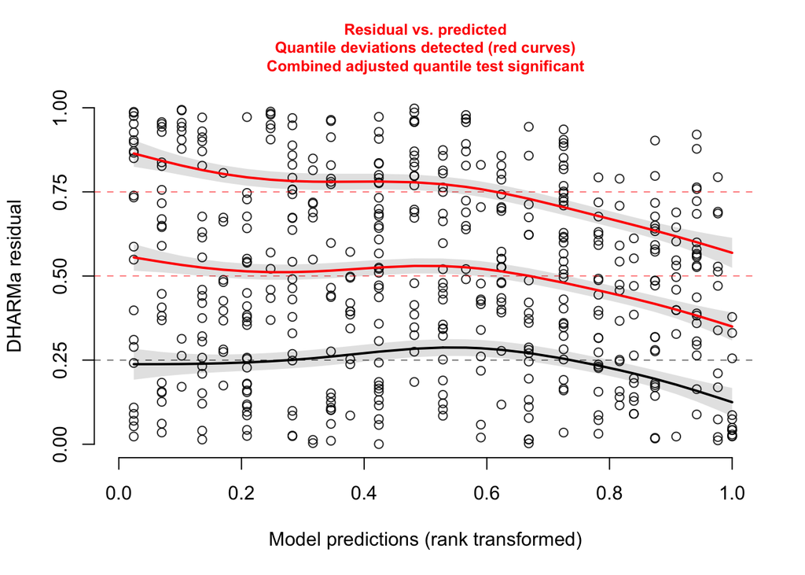

```
##
##  Test for location of quantiles via qgam
##
## data:  simulationOutput
## p-value = 0.000006085
## alternative hypothesis: both
```

```r
testQuantiles(so.ss8a_sr) # p = 0.000006; this is the best so far
```

- From what I’ve read, models with significant quantile deviations can still be good models / used.

### Pairwise for treatment type

```r
emmeans(so.ss8a, specs = pairwise ~ Treat_Type, adjust = 'Tukey', type = 'response')
```

```
## $emmeans
##  Treat_Type response    SE  df asymp.LCL asymp.UCL
##  Control       0.269 0.108 Inf     0.123     0.592
##  FallRx        3.401 1.353 Inf     1.560     7.415
##  Harvest       1.259 0.769 Inf     0.380     4.171
##  MowRx         4.549 1.572 Inf     2.312     8.954
##  SpringRx      4.522 1.946 Inf     1.946    10.509
##
## Confidence level used: 0.95
## Intervals are back-transformed from the log scale
##
## $contrasts
##  contrast            ratio     SE  df null z.ratio p.value
##  Control / FallRx   0.0792 0.0438 Inf    1  -4.583  <.0001
##  Control / Harvest  0.2139 0.1482 Inf    1  -2.226  0.1701
##  Control / MowRx    0.0592 0.0307 Inf    1  -5.445  <.0001
##  Control / SpringRx 0.0596 0.0338 Inf    1  -4.972  <.0001
##  FallRx / Harvest   2.7009 1.9435 Inf    1   1.381  0.6401
##  FallRx / MowRx     0.7476 0.3845 Inf    1  -0.566  0.9800
##  FallRx / SpringRx  0.7521 0.4323 Inf    1  -0.496  0.9878
##  Harvest / MowRx    0.2768 0.1925 Inf    1  -1.847  0.3464
##  Harvest / SpringRx 0.2785 0.2008 Inf    1  -1.773  0.3894
##  MowRx / SpringRx   1.0060 0.5436 Inf    1   0.011  1.0000
##
## P value adjustment: tukey method for comparing a family of 5 estimates
## Tests are performed on the log scale
```

#### MowRX, FallRx, and SpringRx significantly different from Control.

### Graph shrub oak seedling model

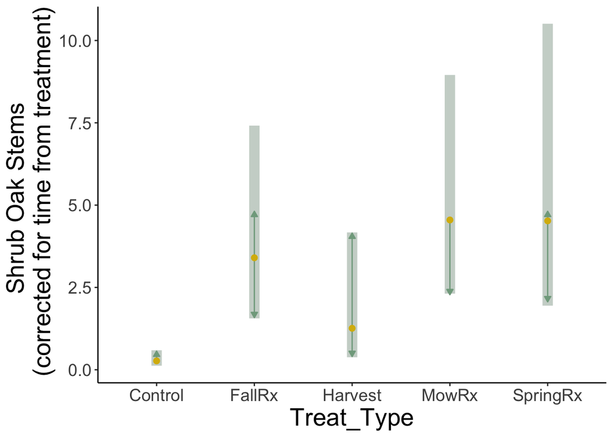